# Bent Winter 2006

R. G. Cronce

12/19/2019

# Bent Brain Ticklers, Winter 2006

## Problem 1

```
One hundred parishioners attended
our church picnic, and 90 had
a hot dog, 80 had potato salad, 70 had
cake, and 60 had ice cream. However,
no one ate all four items. How many
had both cake and ice cream?

-- Classic Mathemagic by
R.A.Blum, A. Hart-Davis, B. Longe,
and D. Niederman
```

Solution: 30 people ate Cake and Ice Cream

```
If no one had all four items
then everyone skipped (at least) one item.


10 people skipped the hot dog
20 people skipped the potato salad
30 people skipped the cake
40 people skipped the ice cream

Total = 100 people skipped something so
each person skipped exactly one item.

The four meals (along with counts) were:

n1 = Hot dog and Potato Salad and Cake
n2 = Hot dog and Potato Salad          and Ice Cream
n3 = Hot dog and                  Cake and Ice Cream
n4 =             Potato Salad and Cake and Ice Cream

We know:

n1+n2+n3 = 90
n1+n2+n4 = 80
n1+n3+n4 = 70
n2+n3+n4 = 60

Solving yields: n1=40, n2=30, n3=20, and n4=10

Cake and Ice Cream = n3+n4 = 30
```

The Bent solution was actually quite interesting. They make the same observation about no overlap in the skipped foods and then make a series of bars that represent the foods and the skipped foods as follows:

```
- = food consumed, X = food skipped

Hot Dog       |X---------|
Potato Salad  |-XX-------|
Cake          |---XXX----|
Ice Cream     |------XXXX|

Since each group is independent we can just look at the Cake and
Ice Cream lines and see that only 30 people ate both.  This is
very elegant.

This also makes it possible to solve the problem by inspection.
Since no person skipped more than one food we know:

10 people skipped the hot-dog      -> they ate Cake and Ice Cream
20 people skipped the potate salad -> they ate Cake and Ice Cream
The other people skipped either Cake or Ice Cream so they did not
eat both.

Trivially, then, the total eating Cake and Ice Cream is 30.
```

## Problem 2

```
Al, Sam, and Ralph play a challenge
tennis tournament in which
two of them play a set, with the
winner staying on the court to play
the person who sat out. In the course
of the tournament, Al played 15
sets, Sam played 14 sets, and Ralph
played 9 sets. Who played in set #13?

-- Richard I. Hess, CA B '62
```

Solution: Al-Sam play in set #13

```
The total number of sets must be
half of the total of the three players:

Number of sets = (15+14+9)/2 = 19 sets

Who could Al have played and how many times.

Al vs Sam = 14 times -> only leaves 1 set for Ralph
Al vs Sam = 13 times -> leaves 3 sets for Ralph
Al vs Sam = 12 times -> leaves 5 sets for Ralph
Al vs Sam = 11 times -> leaves 7 sets for Ralph
Al vs Sam = 10 times -> leaves 9 sets for Ralph

Conclude:

Al played Sam 10 times
Al played Ralph 5 times
Sam played Ralph 4 times

What sequence could generate this?
The following sequence works -- is this unique?

(The Bent argues that Ralph plays 9 times and nobody sits more than
one set in a row so the only way for this to occur is if Ralph
plays in all the even sets.)

Al-Sam play all odd sets
Ralph plays even sets with alternating opponents starting with Al.

Al plays 15 sets:    WWL-WWL-WWL-WWL-WWX
Sam plays 14 sets:   LWW-LWW-LWW-LWW-LX
Ralph plays 9 sets:  all losses

1.  Al-Sam
2.  Al-Ralph
3.  Al-Sam
4.  Sam-Ralph
5.  Al-Sam
6.  Al-Ralph
7.  Al-Sam
8.  Sam-Ralph
9.  Al-Sam
10. Al-Ralph
11. Al-Sam
12. Sam-Ralph
13. Al-Sam
14. Al-Ralph
15. Al-Sam
16. Sam-Ralph
17. Al-Sam
18. Al-Ralph
19. Al-Sam
```

## Problem 3

```
In the following equations, each
letter always has the same value, but
different letters may have the same
value, and values may be positive,
negative, zero, integer, or fractional.
Given that

    U+N=1
    D+E+U+X=2
    T+R+O+I+S=3
    Q+U+A+T+R+E=4
    C+I+N+Q=5
    S+I+X=6
    S+E+P+T=7
    H+U+I+T=8
    N+E+U+F=9
    D+I+X=10
    O+N+Z+E=11
    D+O+U+Z+E=12
    T+R+E+I+Z+E=13
    Q+U+A+T+O+R+Z+E=14
    Q+U+I+N+Z+E=15,

what is the value of S+A+I+N+T+T+R+O+P+E+Z?

-- C.W. Haigh in New Scientist
```

Solution: solved in the cryptic arithmetic notebook

```
Solution set:

u   4.5
n  -3.5
d  -7.0
e   4.5
x   0.0
t -13.5
r   0.5
o  10.0
i  17.0
s -11.0
q  -7.5
a  15.5
c  -1.0
p  27.0
h   0.0
f   3.5
z   0.0

The desired sum: SAINTTROPEZ = 33
```

## Problem 4

```
On my last birthday, I received
a present packed in a rectangular
box, 10 cm by 20 cm by 30 cm. The
box was wrapped by an inelastic
continuous loop of very narrow ribbon
that crossed all six faces at least
once, held in place with transparent
tape, with the total length of ribbon
on each face being at least 1 cm.
What is the shortest ribbon that
meets these requirements? Express
your answer accurate to three decimal
places.

-- James M. Garnett III, MS '65
```

Solution:

```
Seems like the shortest piece would be
a loop that just looped over the top of
opposite corners, ran at an angle down each
side, and make long angular runs along the
bottom.

Need a diagram to figure this out and then
some calculus to minimize.

The Bent hand-waves the minimization step and
just asserts the shortest distance possible.
```

## Problem 5

```
Five friends, Andrew, Bernie,
Cliff, Don, and Ed, each has a son
and a daughter. Their families are
so close that each friend's daughter
is married to the son of one of his
friends. As a result, the daughterin-
law of the father of Andrew's sonin-
law is the sister-in-law of Bernie's
daughter. And, the son-in-law of
the father of Cliff's daughter-in-law
is the brother-in-law of Don's son.
Furthermore, the daughter-in-law
of the father of Bernie's daughter-inlaw
has the same mother-in-law as
the son-in-law of the father of Don's
son-in-law, and the son-in-law of the
father of Ed's son-in-law has the
same father-in-law as the daughterin-
law of the father of Cliff's daughter-
in-law. However, the situation is
simplified by the fact that no daughter-
in-law is the sister-in-law of the
daughter of her father-in-law. Who is
married to whom?

-- 100 Games of Logic by Pierre Berloquin
```

Solution: exhaustive search for all the combinations and then check for contradictions. Just reading this problem hurts my head. **I give up.**

```
According to the Bent solution, there are five
statements.

S1 implies something about A's daughter:
either A's daughter is married to B's son or A's son
is married to B's daughter.

S2 means C's son married to D's daughter or
C's daughter married to D's son.

This leaves 8 possibilities

S3 means B's daughter-in-law's brother is D's
son-in-law -> eliminates 5 of the possibilities.

S4 means C's daughter-in-law's brother is E's
son-in-law -> eliminates 2 more.

The only remaining possibility is:

A's son is married to B's daughter
B's son is married to C's daughter
C's son is married to D's daughter
D's son is married to E's daughter
E's son is married to A's daughter
```

## Bonus

```
A mathematics professor
smokes a pipe. He carries two identical
matchboxes, originally containing
20 matches each. When he lights
his pipe, he selects a matchbox at
random and lights his pipe with one
match and discards the used match.
There will come an occasion when
he first selects a matchbox with only
one match in it. At this point, what is
the expected number of matches in
the other box? Express your answer
accurate to three decimal places.

-- Adapted from An Introduction
to Probability Theory and
Its Applications by William Feller
```

Solution: I think this is the same as the coffee ticket problem from the Riddler.

```
The problem is similar to flipping a coin.  We can
calculate the probabilities of flipping a coin and
having it come up H 20 times in a row -- this would
be like picking every match out of the same box and
ending up with a box with only 1 match.  This
probability is:

0.5^20 = 0.5^20

Now, consider flipping 20 H and one T.  The T can
not be in the final position.  The total number of
items is then 20+1-1, and there is one T so the
total probability is:

Pr(1) = choose(20,1)*0.5^20*(1-0.5)^1 = 20*0.5^21

In general, picking n tails in a row:

Pr(n) = choose(20+n-1,n)*0.5^20*(1-0.5)^n
      = choose(19+n,n)*0.5^(20+n)

The mean value is then: sum(n*Pr(n),n=0 to 19)

This could occur for either box so we need to double the probability.

Finally, this is the mean number picked from the other box so we need
to subtract this from 20 to get the number left over:
```

```r
n=0:19
20-2*sum(n*choose(19+n,n)*0.5^(20+n))
```

```
## [1] 5.014828
```

Conclude: we expect 5.014828 matches left in the other box.

Can we get this by Monte-Carlo?

```r
n_trials=100000

zzz=rep(0,n_trials)
for (trial in 1:n_trials) {
    n_box1=20
    n_box2=20
    while(T) {
        s=sample(2,1)
        if (s==1) {
            if (n_box1==1) {
                n=n_box2
                break
            }
            n_box1=n_box1-1
        } else {
            if (n_box2==1) {
                n=n_box1
                break
            }
            n_box2=n_box2-1
        }
    }
    zzz[trial]=n
}

print(paste0("Mean remaining = ",mean(zzz),collapse=""))
```

```
## [1] "Mean remaining = 5.01742"
```

Ideal result = 5.014828

Monte-Carlo results, 1e5 trials per test:

```
5.00191
5.01455
5.0147
4.99383
5.01945
```

Which are all in the same range as the analytical solution.

The distribution is far from gaussian:

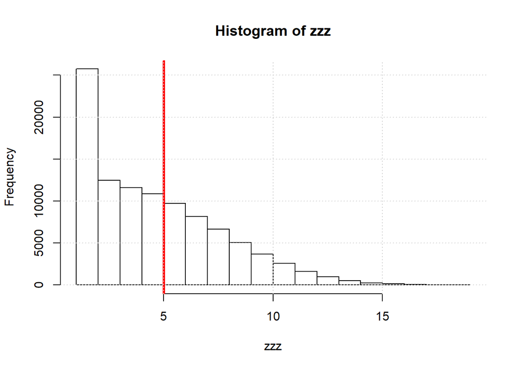

```r
hist(zzz)
abline(v=5.014828,col='red',lwd=3)
grid()
```

## Computer Bonus

```
Solve the following
cryptic multiplication problem.

GEORGE = HW * BUSH

-- H.G. McIlvried III, PA Gamma'53
```

Solution: Somehow missed this in cryptic arithmetic notebook. Not really sure why this is a computer bonus but I will use the computer in any event:

```r
source('rgc_lib.R')

a=make_crypt_df('georgehwbush')

x_george=make_num(a,'george')
x_hw=make_num(a,'hw')
x_bush=make_num(a,'bush')
k=(x_george == x_hw*x_bush) & (a$g != 0) & (a$h !=0) & (a$b !=0)

print(paste0("Number of solutions = ",sum(k),collapse=""))
```

```
## [1] "Number of solutions = 1"
```

```r
print(t(a[k,]))
```

```
##   2802765
## g       7
## e       6
## o       4
## r       0
## h       8
## w       2
## b       9
## u       3
## s       1
```

```r
print_num(a,'george',k)
```

```
## [1] "george = 764076"
```

```r
print_num(a,'hw',k)
```

```
## [1] "hw = 82"
```

```r
print_num(a,'bush',k)
```

```
## [1] "bush = 9318"
```

Solution:

```
george = 764076
hw = 82
bush = 9318
```